# Unsupervised learning - clustering and dimension reduction

After running a gap statistics test on the iris data, it stated that the optimal number of cluster s is 2. This is consistent with what the silouhette plot shows, with two distinct groups being shown. This means that the data clustering is either not based entirely on species, or that two of the species are similar enough to be considered a single cluster. Indeed, after creating a silhouette plot based on the flower species, we observe that two species are closely aligned to one another, and are sidered as a singular cluster.

```r
set.seed(15)

clusGap(iris_pca, kmeans, K.max = 10, B=150)
```

```
## Clustering Gap statistic ["clusGap"] from call:
## clusGap(x = iris_pca, FUNcluster = kmeans, K.max = 10, B = 150)
## B=150 simulated reference sets, k = 1..10; spaceH0="scaledPCA"
##  --> Number of clusters (method 'firstSEmax', SE.factor=1): 2
##           logW   E.logW        gap     SE.sim
##  [1,] 4.551642 4.645977 0.09433569 0.02728004
##  [2,] 3.808397 4.192580 0.38418279 0.02134238
##  [3,] 3.754878 4.014636 0.25975828 0.02179965
##  [4,] 3.368124 3.919867 0.55174299 0.02397617
##  [5,] 3.296871 3.836835 0.53996383 0.02457909
##  [6,] 3.229458 3.765279 0.53582116 0.02367519
##  [7,] 3.230554 3.702935 0.47238123 0.02559356
##  [8,] 3.127738 3.645265 0.51752694 0.02590911
##  [9,] 3.013438 3.601478 0.58804018 0.02576975
## [10,] 3.099541 3.556301 0.45675973 0.02417578
```

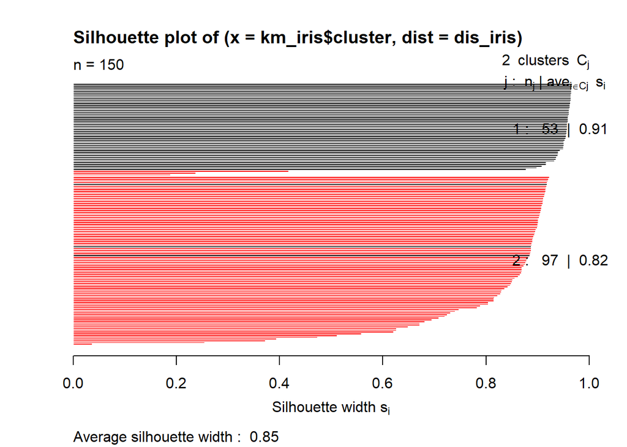

```r
km_iris <- kmeans(new_iris, 2, 150)

dis_iris <- dist(new_iris)^2

sil_iris <- silhouette(km_iris$cluster, dis_iris)
plot(sil_iris, col = km_iris$cluster)
```

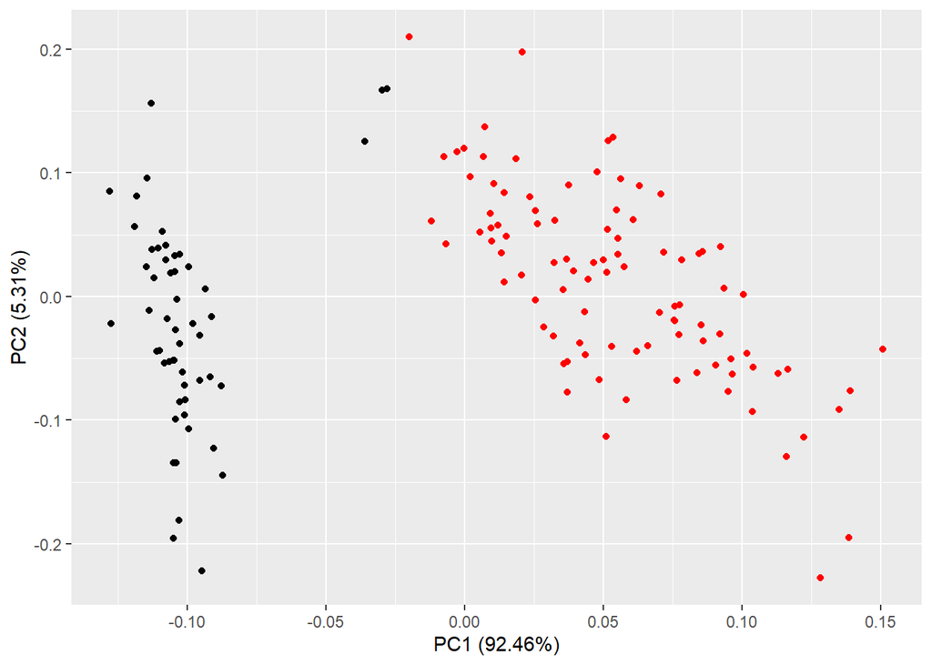

```r
autoplot(prcomp(iris_pca), col=km_iris$cluster)
```

```r
set.seed(15)


vaars1 <- c('Sepal.Length', 'Sepal.Width', 'Petal.Length', 'Petal.Width', 'Species')
test_iris <- iris[vaars1]

iris_df <- data.matrix(test_iris)

clusGap(iris_pca, kmeans, K.max = 10, B=150)
```

```
## Clustering Gap statistic ["clusGap"] from call:
## clusGap(x = iris_pca, FUNcluster = kmeans, K.max = 10, B = 150)
## B=150 simulated reference sets, k = 1..10; spaceH0="scaledPCA"
##  --> Number of clusters (method 'firstSEmax', SE.factor=1): 2
##           logW   E.logW        gap     SE.sim
##  [1,] 4.551642 4.645977 0.09433569 0.02728004
##  [2,] 3.808397 4.192580 0.38418279 0.02134238
##  [3,] 3.754878 4.014636 0.25975828 0.02179965
##  [4,] 3.368124 3.919867 0.55174299 0.02397617
##  [5,] 3.296871 3.836835 0.53996383 0.02457909
##  [6,] 3.229458 3.765279 0.53582116 0.02367519
##  [7,] 3.230554 3.702935 0.47238123 0.02559356
##  [8,] 3.127738 3.645265 0.51752694 0.02590911
##  [9,] 3.013438 3.601478 0.58804018 0.02576975
## [10,] 3.099541 3.556301 0.45675973 0.02417578
```

```r
km_iris1 <- kmeans(new_iris, 2, 150)
km_iris1$cluster
```

```
##   [1] 1 1 1 1 1 1 1 1 1 1 1 1 1 1 1 1 1 1 1 1 1 1 1 1 1 1 1 1 1 1 1 1 1 1 1
##  [36] 1 1 1 1 1 1 1 1 1 1 1 1 1 1 1 2 2 2 2 2 2 2 1 2 2 2 2 2 2 2 2 2 2 2 2
##  [71] 2 2 2 2 2 2 2 2 2 2 2 2 2 2 2 2 2 2 2 2 2 2 2 1 2 2 2 2 1 2 2 2 2 2 2
## [106] 2 2 2 2 2 2 2 2 2 2 2 2 2 2 2 2 2 2 2 2 2 2 2 2 2 2 2 2 2 2 2 2 2 2 2
## [141] 2 2 2 2 2 2 2 2 2 2
```

```r
dis_iris1 <- dist(test_iris)^2
```

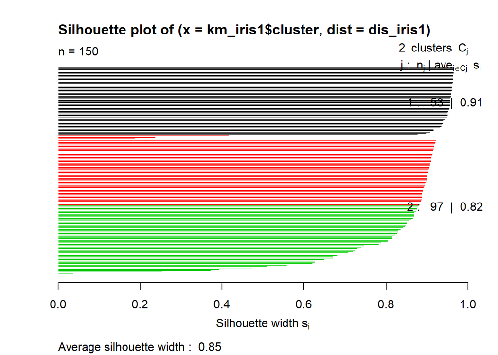

```r
sil_iris1 <- silhouette(km_iris1$cluster, dis_iris1)
plot(sil_iris1, col = test_iris$Species)
```

5. Use hierarchical clustering to cluster the Iris data.
- Try two different linkage types, and two different distance metrics.
- For one linkage type and one distance metric, try two different cut points.
- Using this clustering, color the PCA plot according to the clusters. (6 plots in total)

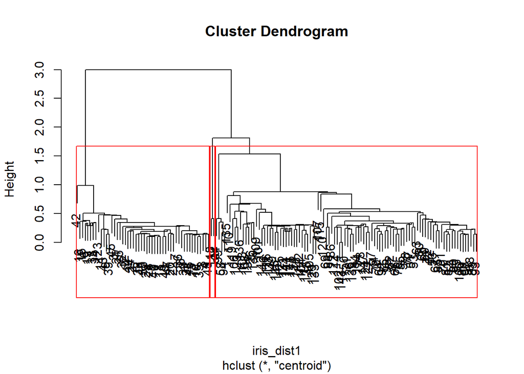

```r
iris_dist1 <- dist(new_iris, method = "euclidean")
tree1 <- hclust(iris_dist1, method="centroid")
plot(tree1)

tree_k1 <- cutree(tree1, k = 3)
# plot the tree before running this line
rect.hclust(tree1, k = 3, h = NULL)
```

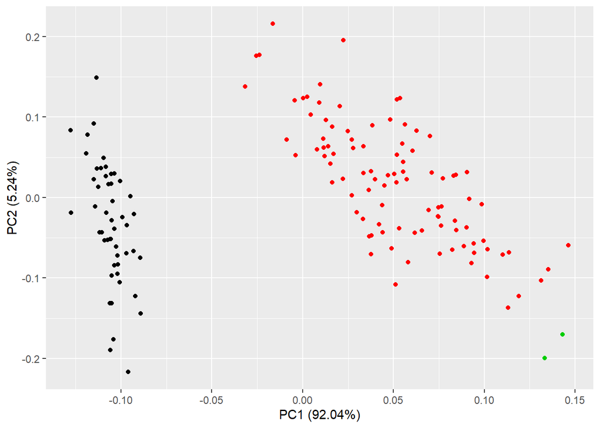

```r
tree_iris1 <- cbind(new_iris, tree_k1)



autoplot(prcomp(tree_iris1), col = tree_iris1$tree_k1)
```

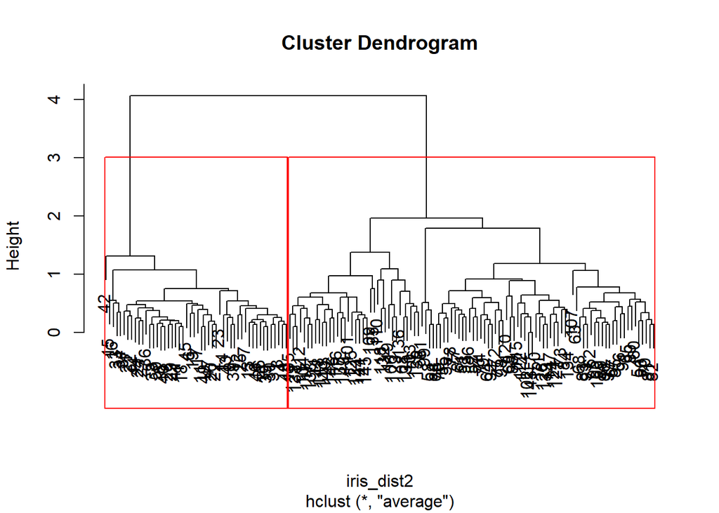

```r
iris_dist2 <- dist(new_iris, method = "euclidean")
tree2 <- hclust(iris_dist2, method="average")
plot(tree2)

tree_k2 <- cutree(tree2, k = 3, h = 2)
rect.hclust(tree2, h = 2)
```

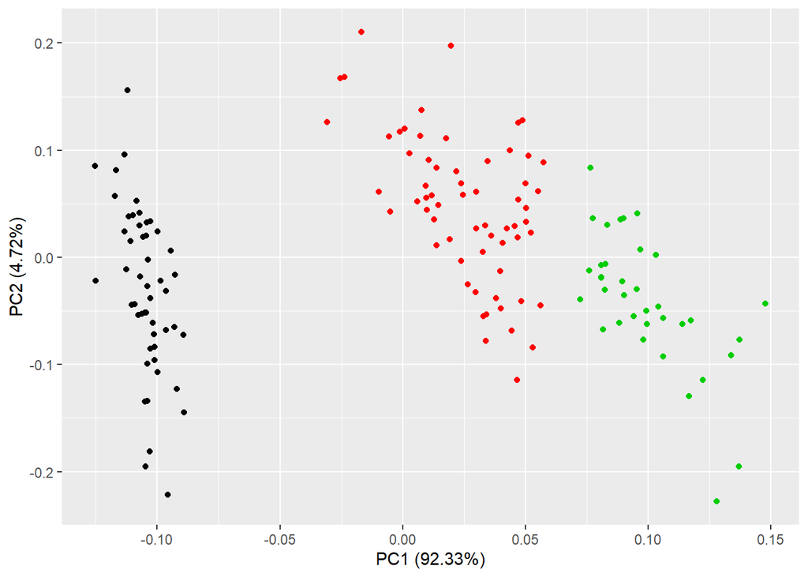

```r
tree_iris2 <- cbind(new_iris, tree_k2)



autoplot(prcomp(tree_iris2), col = tree_iris2$tree_k2)
```

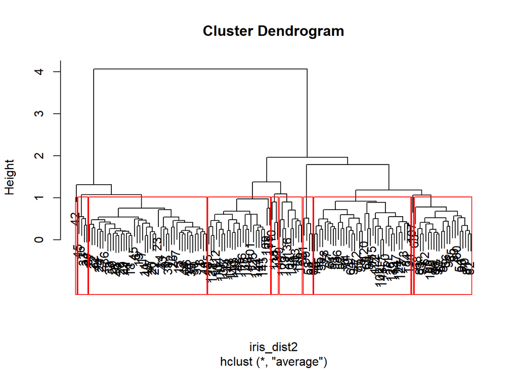

```r
tree22 <- hclust(iris_dist2, method="average")
plot(tree22)


tree_k22 <- cutree(tree22, h = 3)
rect.hclust(tree22, h = 1)
```

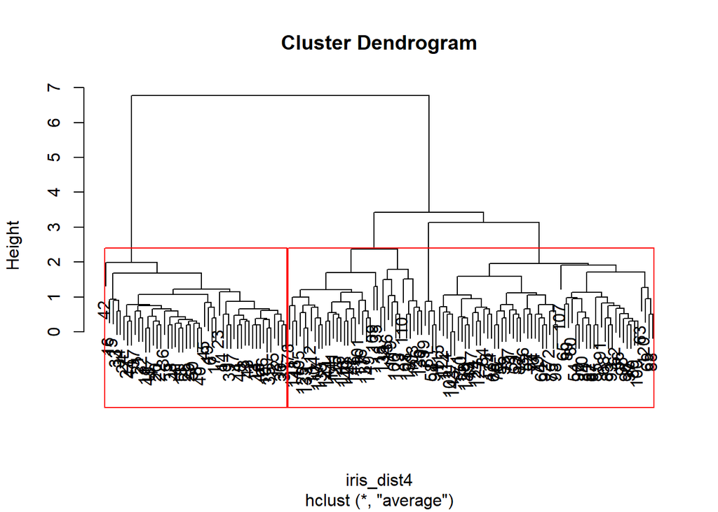

```r
iris_dist4 <- dist(new_iris, method = "manhattan")
tree4 <- hclust(iris_dist4, method="average")
plot(tree4)

tree_k4 <- cutree(tree4, k = 3)
# plot the tree before running this line
rect.hclust(tree1, h = 3)
```

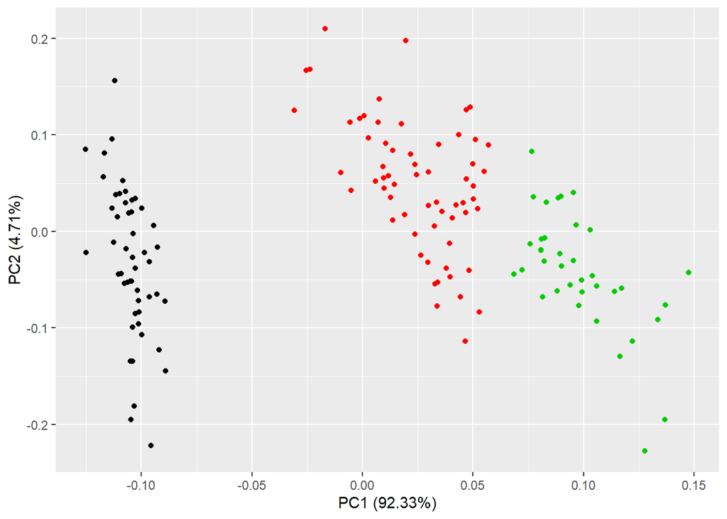

```r
tree_iris4 <- cbind(new_iris, tree_k4)



autoplot(prcomp(tree_iris4), col = tree_iris4$tree_k4)
```

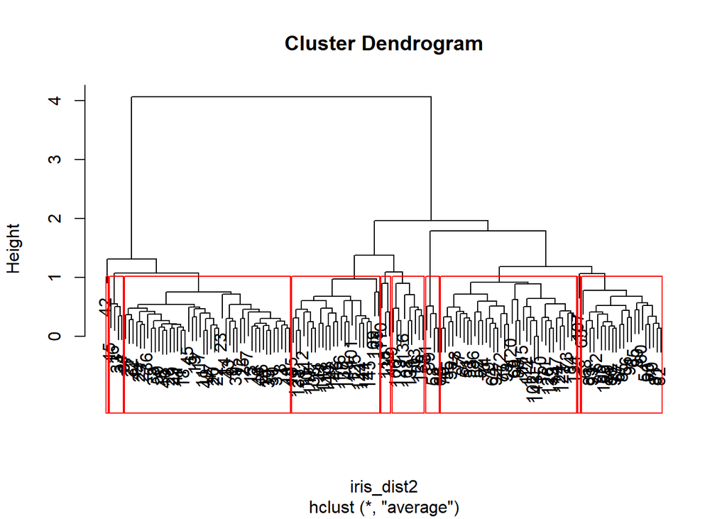

```r
tree42 <- hclust(iris_dist2, method="average")
plot(tree42)


tree_k22 <- cutree(tree22, h = 1)
rect.hclust(tree22, h = 1)
```

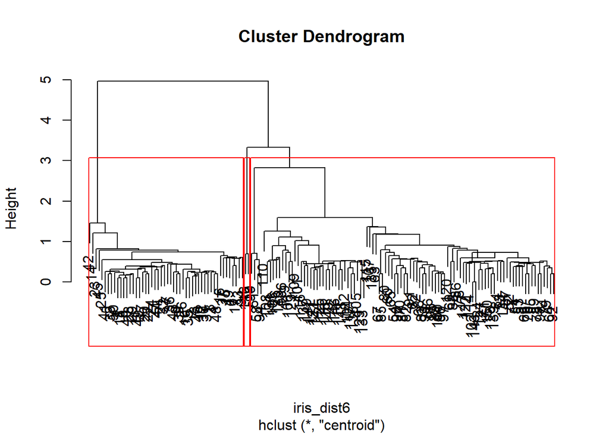

```r
iris_dist6 <- dist(new_iris, method = "manhattan")
tree6<- hclust(iris_dist6, method="centroid")
plot(tree6)

tree_k6 <- cutree(tree6, k = 3)
# plot the tree before running this line
rect.hclust(tree6, k = 3, h = NULL)
```

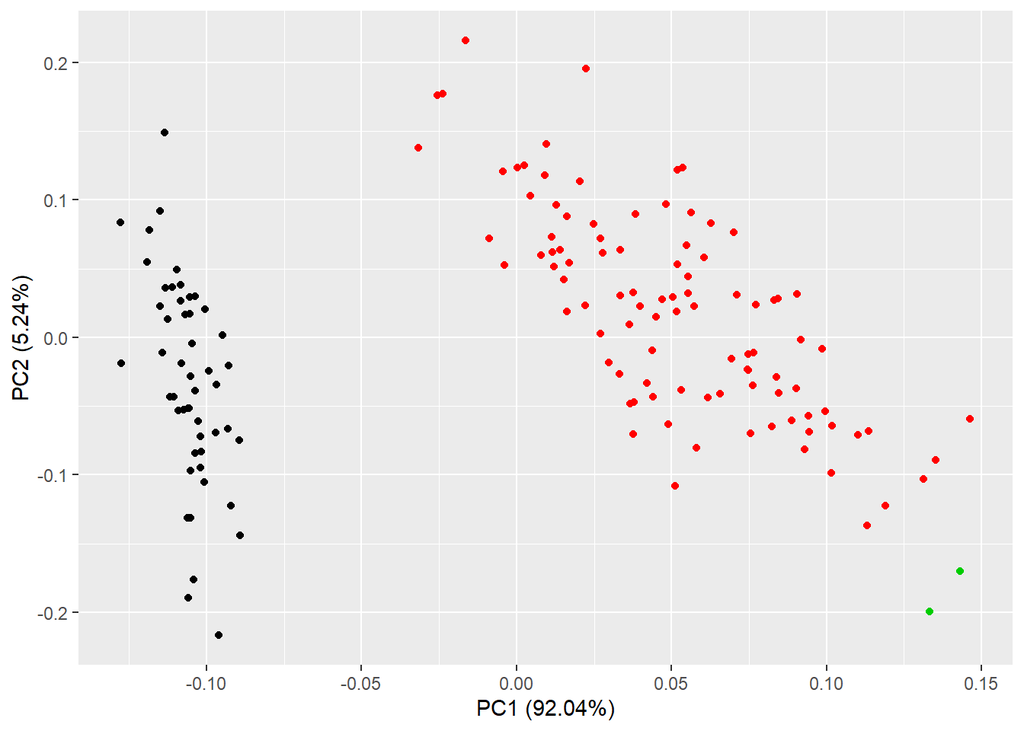

```r
tree_iris6 <- cbind(new_iris, tree_k6)


autoplot(prcomp(tree_iris6), col = tree_iris6$tree_k6)
```